# 角度追蹤：平行線、8字型、飛鏢型、轉角

> 來源整理：改國二下5_三角形的內角與外角_易讀版.md

## 內外角基本角度追蹤

> 學習目標：角度追蹤不是靠猜，而是反覆使用 180°、外角定理與對頂角。

### 先抓住核心

- 先把所有能直接用的三角形內角和算出來。
- 看到延長線，就檢查外角定理或平角互補。
- 看到交叉線，就檢查對頂角相等。
- 同一題可能有兩條路：外角定理與平行線性質常能互相驗證。
- 計算過程要標明用的是內角和、外角定理、平角或對頂角。

### 解題流程

1. 先找完整三角形，補出缺角。
2. 再找外角，套外角定理。
3. 遇到交點，補上對頂角相等。
4. 最後用平角或周角檢查答案是否合理。

### 公式、性質與判斷

- **內角和**：缺角 = 180° - 另外兩角。
- **外角定理**：外角 = 兩內對角和。
- **對頂角**：對頂角相等。

### 例題拆解

- 若 ∠1 = 180° - 58° - 70°，則 ∠1 = 52°。
- 若 ∠4 = 75° + 35°，則 ∠4 = 110°。
- 若某角是 152° 的外角差，152° - 110° = 42°。

### 易錯提醒

- 看到外角就直接減錯角，沒有先確認內對角。
- 算出新角後沒有回圖上標記，導致下一步重複或漏算。

### 小練一下

- 若三角形兩角為 48°、72°，第三角是多少？
- 若外角為 135°，其中一內對角為 50°，另一內對角是多少？

### 記憶鉤子

- 角度追蹤像接力：每算出一個角，就可能解鎖下一個角。
- 每一步都問自己：我用的是 180°、外角、對頂角，還是平行線？

### 圖像化理解

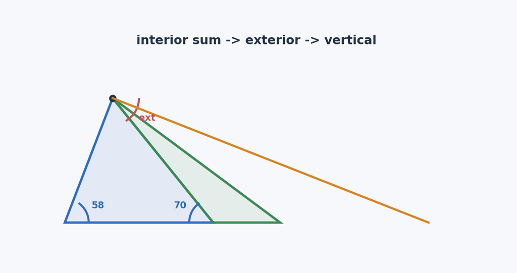

內外角基本角度追蹤

圖解：用一個多三角形圖示意內角和、外角定理與對頂角如何接力。

## 平行線搭配三角形角度

> 學習目標：平行線可以把角搬到另一個位置，再用三角形定理收尾。

### 先抓住核心

- 若題目給兩線平行，先找同位角、內錯角、同側內角。
- 平行線常把某個角轉換成三角形內角或外角。
- 同側內角互補常會出現 180° - 已知角。
- 平行四邊形條件也可能由兩組對邊平行推出，再利用對角相等。
- 平行線方法和外角定理方法常可得到同一答案。

### 解題流程

1. 標出平行線。
2. 找截線，判斷同位角、內錯角、同側內角。
3. 把已知角搬到三角形上。
4. 用三角形內角和或外角定理求目標角。

### 公式、性質與判斷

- **內錯角**：平行線下內錯角相等。
- **同側內角**：平行線下同側內角互補。
- **平行四邊形**：兩組對邊平行可推出平行四邊形。

### 例題拆解

- 若 ∠1 = 80°，與它同側內角互補的角是 100°。
- 若 ∠2 = 40°，再搭配 100°，可在三角形中求出剩下角。
- 若 AB // CD 且 AC // BD，則 ABCD 是平行四邊形，可利用對角相等。

### 易錯提醒

- 忘記先確認平行，就直接套平行線角度性質。
- 同側內角應該互補，卻誤算成相等。

### 小練一下

- 平行線中同側內角的和是多少？
- 兩組對邊互相平行時，四邊形至少是什麼？

### 記憶鉤子

- 平行線題先搬角，三角形題再算角。
- 有兩種解法時，用另一種方法驗算很可靠。

### 圖像化理解

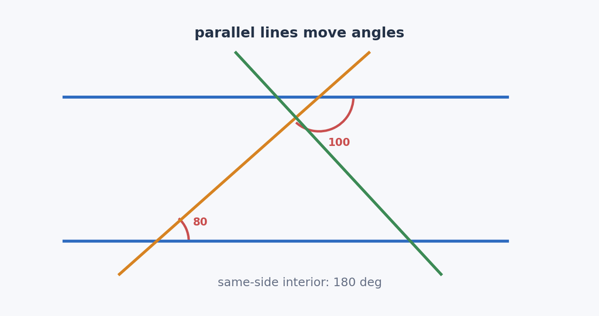

平行線搭配三角形角度

圖解：用平行線與三角形疊合圖示意角度搬移。

## 8字型定理

> 學習目標：兩個三角形在交點形成 8 字形時，可以用對頂角相等消掉中間角。

### 先抓住核心

- 8 字型常由兩條線交叉形成兩個三角形。
- 兩個三角形的中間角是一組對頂角，所以相等。
- 因為兩個三角形內角和都等於 180°，扣掉相等的中間角後，剩下兩角和相等。
- 常見形式：∠1 + ∠2 = ∠5 + ∠6。
- 8 字型定理很適合處理多角總和，把遠端角換成另一組角。

### 解題流程

1. 找出交叉形成的兩個三角形。
2. 標出中間對頂角。
3. 兩個三角形各寫內角和 180°。
4. 利用對頂角相等，得到兩端角和相等。

### 公式、性質與判斷

- **8字型定理**：一邊兩角和 = 另一邊兩角和。
- **理由**：三角形內角和 + 對頂角相等。

### 例題拆解

- 若 ∠A + ∠B = ∠E + ∠D，且 ∠A = 3x、∠B = x、∠D = x，則 ∠E = 3x。
- 在多角總和題中，可用 8 字型把外側兩角換成內部兩角。
- 若 ∠D + ∠E = ∠1 + ∠2，總角度就能被收回到一個多邊形或三角形內。

### 易錯提醒

- 把 8 字型定理誤用成所有對應角都相等。
- 沒有確認中間角是對頂角，就直接消掉。

### 小練一下

- 8 字型定理使用了哪兩個基本事實？
- 8 字型定理通常得到的是單角相等還是兩角和相等？

### 記憶鉤子

- 8 字型不要硬背圖形，抓住『兩個三角形共用對頂角』。
- 遇到兩條線交叉，先看看能不能切出 8 字型。

### 圖像化理解

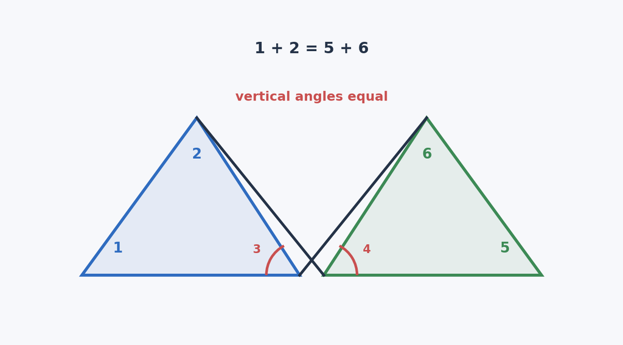

8字型定理

圖解：畫出兩個交叉三角形，標示中間對頂角與兩端角和。

## 箭頭定理

> 學習目標：箭頭形角度題可用外角定理拆成多個小外角，最後得到尖端大角等於幾個底部角相加。

### 先抓住核心

- 箭頭形常由凹進去或折線形成一個大角。
- 透過作輔助線，可以把大角拆成兩個外角。
- 每個外角再用外角定理換成內對角和。
- 常見形式：∠D = ∠A + ∠B + ∠C。
- 箭頭定理常用來處理凹四邊形、折線角度與多角相加題。

### 解題流程

1. 找出箭頭尖端的大角。
2. 必要時連輔助線，把圖形拆成兩個三角形。
3. 分別使用外角定理。
4. 把兩個外角結果相加，得到箭頭角公式。

### 公式、性質與判斷

- **箭頭定理**：箭頭尖端角 = 其餘相關三角角度相加。
- **常見式**：D = A + B + C。

### 例題拆解

- 若 150° = 55° + 25° + x，則 x = 70°。
- 若 ∠DEF = 22° + 28° + 80°，則 ∠DEF = 130°。
- 若先用內角和算出中間角 80°，再套箭頭定理，能快速求大角。

### 易錯提醒

- 把箭頭尖端角和周角 360° 混用。
- 沒有分清楚哪些角是箭頭定理中的底部角。

### 小練一下

- 箭頭定理常用哪一個基本定理推導？
- 若 D = 40° + 35° + 50°，D 是多少？

### 記憶鉤子

- 箭頭定理本質是外角定理的連續使用。
- 看到凹進去的大角，先想能不能畫輔助線拆三角形。

### 圖像化理解

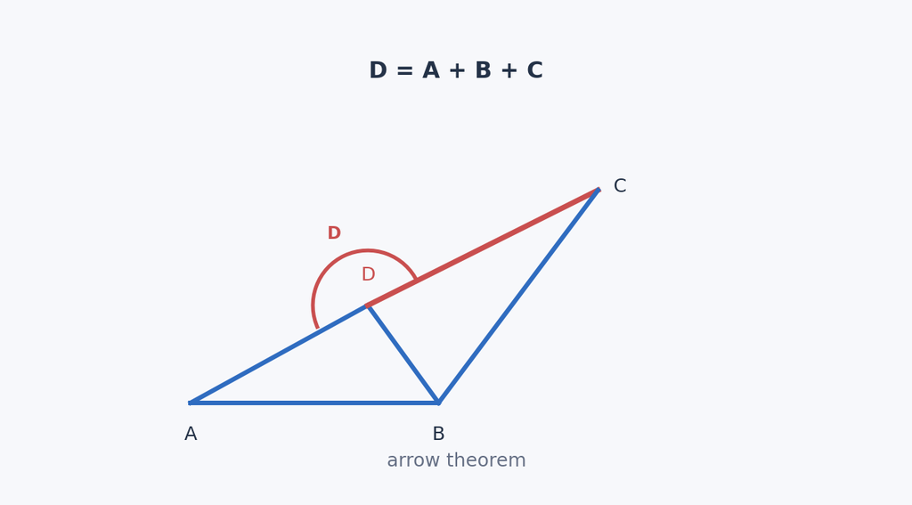

箭頭定理

圖解：用輔助線把箭頭形拆成兩個外角，示意 D = A+B+C。

## 多角總和與輔助線

> 學習目標：多角總和題不要逐角硬算，通常要用輔助線把外面的角收回到熟悉圖形中。

### 先抓住核心

- 多角總和題常出現五角、七角或九角相加。
- 可用 8 字型定理把外側角轉成內側角。
- 可連接輔助線，把圖形切成三角形或多邊形。
- 五邊形內角和是 (5-2)*180° = 540°。
- 有些圖形最後會收回到一個三角形，總和變成 180°。

### 解題流程

1. 先觀察角都分布在外圍還是內部。
2. 找交叉處，嘗試套 8 字型定理。
3. 連接輔助線，把零散角移入同一個多邊形。
4. 使用多邊形內角和或三角形內角和收尾。

### 公式、性質與判斷

- **n邊形內角和**：(n-2)*180°。
- **三角形內角和**：180°。
- **五邊形內角和**：540°。

### 例題拆解

- 若多角總和可化成五邊形內角和，答案是 540°。
- 若外側角可用 8 字型全部收回到一個三角形，答案是 180°。
- 九個角總和題可連接三角形內部輔助線，把外角和換回三角形角。

### 易錯提醒

- 把所有看到的角直接加 180° 或 360°，沒有判斷圖形。
- 輔助線連了卻沒有說明用來形成哪個三角形或多邊形。

### 小練一下

- 五邊形內角和是多少？
- 多角總和題為什麼常要連輔助線？

### 記憶鉤子

- 多角總和題的技巧不是算很多角，而是把角搬回熟悉的圖形。
- 看到一堆角相加，先找 8 字型和可連的輔助線。

### 圖像化理解

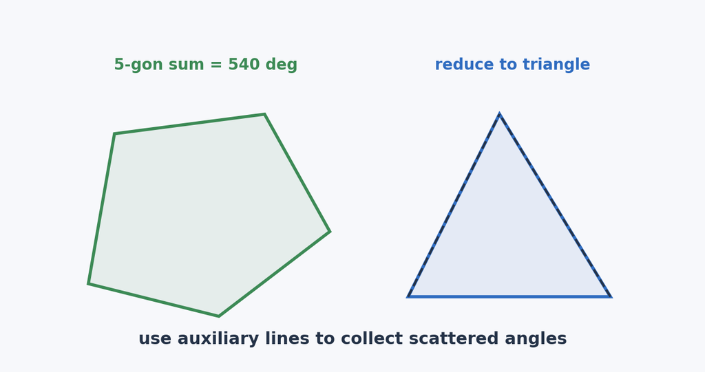

多角總和與輔助線

圖解：示意如何用 8 字型與輔助線把多角總和化成三角形或五邊形角和。

## 摺紙、蛙形與外角和應用

> 學習目標：摺紙或路徑外觀很複雜時，可以把局部角度轉成外角，再用外角和 360° 收尾。

### 先抓住核心

- 摺紙題常保留相等角或相等線段。
- 蛙形或折線圖案常可用外角定理把多個角轉成少數外角。
- n 邊形一組外角和為 360°。
- 若某個內角 I = 92°，它相鄰的外角是 180° - 92° = 88°。
- 若其餘角度總和等於 360° 減掉這個外角，就可得到 272°。

### 解題流程

1. 先把摺紙或圖案中的相等角標出。
2. 延長邊，找出可使用的外角。
3. 用外角定理把內部角轉成外角和。
4. 使用外角和 360° 扣掉已知外角。

### 公式、性質與判斷

- **n邊形外角和**：360°。
- **相鄰外角**：外角 = 180° - 內角。
- **例**：360° - (180° - 92°) = 272°。

### 例題拆解

- 若 ∠I = 92°，相鄰外角是 88°。
- 若多角總和等於一圈外角扣掉 88°，答案是 272°。
- 摺紙題中的對應角常相等，可以先標記再做角度追蹤。

### 易錯提醒

- 把外角和跟內角和混淆。
- 摺紙題沒有先標相等角，直接硬算。

### 小練一下

- n 邊形一組外角和是多少？
- 若內角是 100°，相鄰外角是多少？

### 記憶鉤子

- 複雜圖案不要怕，找外角和通常能把一圈收乾淨。
- 摺紙保留對應角，外角和提供總量。

### 圖像化理解

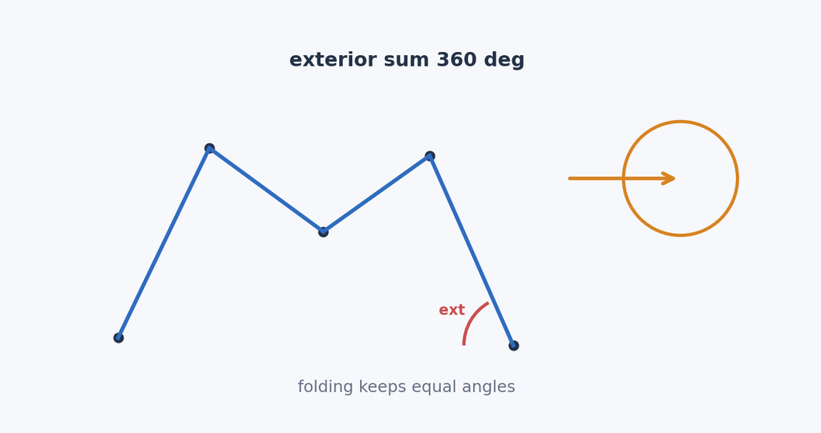

摺紙、蛙形與外角和應用

圖解：用折線外角和示意蛙形題如何由 360° 扣掉一個外角。